# RNAseq processing and differential expression

Jana Braunger

2022-05-26

# Contents

```r
library(tidyverse)
library(magrittr)
library(tximeta)
library(DESeq2)
library(UpSetR)
library(pheatmap)
library(RColorBrewer)
library(ggfortify)
library(glmnet)
library(EnhancedVolcano)
library(umap)
library(ggbeeswarm)
```

This markdown is based on [this](https://master.bioconductor.org/packages/release/workflows/vignettes/rnaseqGene/inst/doc/rnaseqGene.html) vignette and describes the processing of the FASTQ files from the RNAseq data of Fleischer et al., as well as performing a differential expression analysis. The differentially expressed genes are then used for building Steiner trees.

# 1 FASTQ files

The FASTQ files from the study from [Fleischer et al.](https://www.ncbi.nlm.nih.gov/pmc/articles/PMC6300908/) were downloaded from the European Nucleotide Archive [ENA](https://www.ebi.ac.uk/ena/browser/home). The used accession numbers were: SRR7093809 - SRR7093951

# 2 Transcript quantification with Salmon

For the transcript quantification the tool salmon was used according to [this](https://combine-lab.github.io/salmon/getting_started/) vignette. For the quantification, first a reference transcriptome is needed for the alignment. A human reference transcriptome can be downloaded from [ensemblgenomes](http://ftp.ensembl.org/pub/release-105/fasta/homo_sapiens/cdna/Homo_sapiens.GRCh38.cdna.all.fa.gz). Release 105 was used instead of the newest one 106 because tximeta only works for versions up to 105 at the moment. Then salmon was used to build an index on that transcriptome (salmon index -t ../genome_data/Homo_sapiens.GRCh38.cdna.all.fa.gz -i grch38_index). Finally, the samples were quantified with: salmon quant -i grch38_index -l A -r /mnt/jana/fastq/{sample}.fastq.gz -p 8 –validateMappings -o quants/{sample}_quant. This command produces an output folder for each sample that contains the quant.sf file, which includes the count values, used in the following.

# 3 Obtaining count data

## 3.1 Reading in data with tximeta

```r
#20-bins
age_groups <- data.frame(Age = as.character(seq(1, 96, 1)),
                         age_group = c(rep('1-19', 19), rep('20-39', 20),
                                       rep('40-59', 20), rep('60-79', 20),
                                       rep('80-96', 17)))
#same number of patients per bin
age_groups <- data.frame(Age = as.character(seq(1, 96, 1)),
                         age_group = c(rep('1-19', 19), rep('20-35', 16),
                                       rep('36-61', 26), rep('62-84', 23),
                                       rep('85-96', 12)))

#small-big-small
age_groups <- data.frame(Age = as.character(seq(1, 96, 1)),
                         age_group = c(rep('1-9', 9), rep('10-29', 20),
                                       rep('30-59', 30), rep('60-79', 20),
                                       rep('80-89', 10), rep('90-96', 7)))

age_groups <- data.frame(Age = as.character(seq(1, 96, 1)),
                         age_group = c(rep('1-15', 15), rep('16-37', 22),
                                      rep('38-57', 20), rep('58-85', 28),
                                      rep('86-96', 11)))

age_groups <- data.frame(Age = as.character(seq(1, 96, 1)),
                         age_group = c(rep('1-15', 15), rep('16-26', 11),
                                      rep('27-60', 34), rep('61-85', 25),
                                      rep('86-96', 11)))
```

```r
# get info about the runs
runs_info <- read.delim(paste0(dir, "Data/SraRunTable.txt"), sep = ",") %>%
  mutate(Age = gsub("y[rs]\\d+mos", "", Age)) %>%
  mutate(Age = gsub("yr", "", Age)) %>%
  left_join(age_groups) %>%
  mutate(age_group = factor(age_group, levels = unique(age_groups$age_group))) %>%
  filter(disease == "Normal")
  #filter(sex == "male")
head(runs_info, n = 3)
```

```
##          Run Age Assay.Type AvgSpotLen      Bases  BioProject    BioSample
## 1 SRR7093810  12    RNA-Seq         75 1538664000 PRJNA454681 SAMN09011820
## 2 SRR7093812  25    RNA-Seq         75 1495228725 PRJNA454681 SAMN09011818
## 3 SRR7093815  26    RNA-Seq         75 1595644800 PRJNA454681 SAMN09011815
##       Bytes cell_id Center.Name Consent DATASTORE.filetype DATASTORE.provider
## 1 574146143 AG16409         GEO  public          sra,fastq         ncbi,gs,s3
## 2 540157644 AG09975         GEO  public          fastq,sra         gs,s3,ncbi
## 3 600307232 AG07124         GEO  public          sra,fastq         gs,ncbi,s3
##                 DATASTORE.region disease Experiment GEO_Accession..exp.
## 1 s3.us-east-1,gs.US,ncbi.public  Normal SRX4022457          GSM3124561
## 2 gs.US,s3.us-east-1,ncbi.public  Normal SRX4022459          GSM3124563
## 3 gs.US,ncbi.public,s3.us-east-1  Normal SRX4022462          GSM3124566
##    Instrument LibraryLayout LibrarySelection  LibrarySource     Organism
## 1 NextSeq 500        SINGLE             cDNA TRANSCRIPTOMIC Homo sapiens
## 2 NextSeq 500        SINGLE             cDNA TRANSCRIPTOMIC Homo sapiens
## 3 NextSeq 500        SINGLE             cDNA TRANSCRIPTOMIC Homo sapiens
##   Platform          ReleaseDate Sample.Name    sex SRA.Study       source_name
## 1 ILLUMINA 2018-11-17T00:00:00Z  GSM3124561   male SRP144355 Skin; Unspecified
## 2 ILLUMINA 2018-11-17T00:00:00Z  GSM3124563   male SRP144355         Skin; Arm
## 3 ILLUMINA 2018-11-17T00:00:00Z  GSM3124566 female SRP144355         Skin; Arm
##   Ethnicity age_group
## 1 Caucasian      1-15
## 2 caucasian     16-26
## 3 Caucasian     16-26
```

```r
runs_info$names <- runs_info$Run
runs_info$files <- paste0(dir, "Data/rna_counts/", runs_info$names, "_quant/quant.sf")
#file.exists(runs_info$files)
```

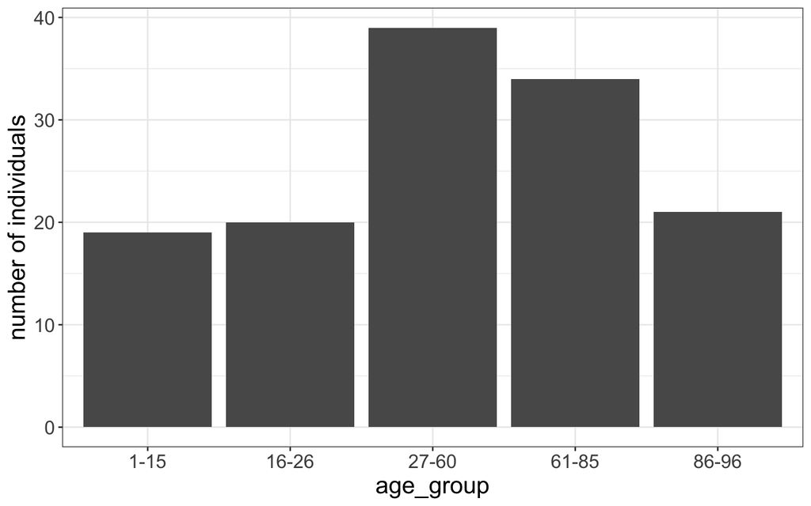

```r
runs_info %<>% mutate(Age = as.numeric(Age))

ggplot(runs_info, aes(x = age_group)) +
  geom_bar() +
  theme_bw() +
  ylab('number of individuals') +
  theme(text = element_text(size = 17))
```

```r
# create summarized experiment with tximeta
se <- tximeta(runs_info)
```

```
## importing quantifications
```

```
## reading in files with read_tsv
```

```
## 1 2 3 4 5 6 7 8 9 10 11 12 13 14 15 16 17 18 19 20 21 22 23 24 25 26 27 28 29 30 31 32 33 34 35 36 37 38 39 40 41 42 43 44 45 46 47 48 49 50 51 52 53 54 55 56 57 58 59 60 61 62 63 64 65 66 67 68 69 70 71 72 73 74 75 76 77 78 79 80 81 82 83 84 85 86 87 88 89 90 91 92 93 94 95 96 97 98 99 100 101 1…
## found matching transcriptome:
## [ Ensembl - Homo sapiens - release 105 ]
## loading existing EnsDb created: 2022-05-24 14:09:17
## loading existing transcript ranges created: 2022-05-24 14:09:20
```

```r
# convert from ensembl transcript id to gene id
gse <- summarizeToGene(se)
```

```
## loading existing EnsDb created: 2022-05-24 14:09:17
## obtaining transcript-to-gene mapping from database
## loading existing gene ranges created: 2022-05-24 14:10:30
## summarizing abundance
## summarizing counts
## summarizing length
```

```r
gse <- gse[rowData(gse)$gene_biotype == "protein_coding", ]

# filter for genes that have counts of at least 10 in at least 5 samples
keep <- rowSums(assay(gse) >= 10) >= 5
gse <- gse[keep,]

#keep2 <- rowMax(assay(gse)) /rowMin(assay(gse)) > 5
#gse <- gse[keep2,]

assay(gse)[1:5, 1:5]
```

```
##                 SRR7093810 SRR7093812 SRR7093815 SRR7093817 SRR7093819
## ENSG00000000003    357.013    450.912    588.386    557.761    592.659
## ENSG00000000419    622.399    648.336    690.053    635.352    836.884
## ENSG00000000457    218.196    179.125    191.908    226.061    272.195
## ENSG00000000460    121.005    256.007    357.007    358.488    543.658
## ENSG00000000971    175.001    367.989    369.000    624.000    177.999
```

```r
dim(assay(gse))
```

```
## [1] 15337   133
```

# 4 Differential expression analysis with DESeq2

```r
dds <- DESeqDataSet(gse, design = ~ age_group)
```

```
## using counts and average transcript lengths from tximeta
```

```
##   Note: levels of factors in the design contain characters other than
##   letters, numbers, '_' and '.'. It is recommended (but not required) to use
##   only letters, numbers, and delimiters '_' or '.', as these are safe characters
##   for column names in R. [This is a message, not a warning or an error]
```

```r
# differential expression analysis
dds <- DESeq(dds)
```

```
##   Note: levels of factors in the design contain characters other than
##   letters, numbers, '_' and '.'. It is recommended (but not required) to use
##   only letters, numbers, and delimiters '_' or '.', as these are safe characters
##   for column names in R. [This is a message, not a warning or an error]
```

```
## using 'avgTxLength' from assays(dds), correcting for library size
```

[output not shown]

[output not shown]

[output not shown]

```
## -- replacing outliers and refitting for 221 genes
## -- DESeq argument 'minReplicatesForReplace' = 7
## -- original counts are preserved in counts(dds)
```

[output not shown]

[output not shown]

```r
foldchanges <- lapply(seq(1, length(unique(age_groups$age_group))-1, 1), function(ix) {
    t0 = unique(age_groups$age_group)[ix]
    t1 <- unique(age_groups$age_group)[ix+1]
    # calculate log2 foldchange between two age intervals
    res <- results(dds, contrast=c("age_group", t0, t1))
    res$gene <- rowData(dds)$symbol
    res$transition <- paste0('fc_', t0, '_', t1)
    res <- subset(res, select = c(gene, transition, log2FoldChange, padj)) %>%
      as.data.frame() %>%
      rownames_to_column(var = "ensembl_id") %>%
      filter(gene != "")
  return(res)}) %>%
  bind_rows() %>%
  mutate(abs_log2_fc = abs(log2FoldChange)) %>%
  arrange(desc(abs_log2_fc)) %>%
  drop_na(padj)

head(foldchanges)
```

```
##        ensembl_id    gene     transition log2FoldChange         padj
## 1 ENSG00000154839    SKA1 fc_16-26_27-60      -50.00218 4.762580e-64
## 2 ENSG00000228177 C6orf47 fc_16-26_27-60      -42.60803 6.565354e-17
## 3 ENSG00000278259   MYO19 fc_61-85_86-96      -38.90985 8.476039e-66
## 4 ENSG00000278259   MYO19 fc_27-60_61-85       36.81495 4.033773e-82
## 5 ENSG00000276023  DUSP14 fc_61-85_86-96      -33.20129 6.228426e-23
## 6 ENSG00000204592   HLA-E fc_61-85_86-96      -32.25490 3.429798e-11
##   abs_log2_fc
## 1    50.00218
## 2    42.60803
## 3    38.90985
## 4    36.81495
## 5    33.20129
## 6    32.25490
```

## 4.1 Number of DE genes per transition

```r
group_by(foldchanges, transition) %>%
  summarize("p<0.01" = length(which(padj < 0.01)),
            "p<0.05" = length(which(padj < 0.05)),
            "p<0.1" = length(which(padj < 0.1)),
            "p<0.2" = length(which(padj < 0.2)))
```

```
## # A tibble: 4 × 5
##   transition     `p<0.01` `p<0.05` `p<0.1` `p<0.2`
##   <chr>             <int>    <int>   <int>   <int>
## 1 fc_1-15_16-26       126      414     745    1545
## 2 fc_16-26_27-60       28      142     336     631
## 3 fc_27-60_61-85       48      161     327     834
## 4 fc_61-85_86-96     7034     8490    9308   10309
```

## 4.2 Robustness of selected DE genes

```r
DE_subsampling <- read.delim(paste0(dir, "Data/subsampling_DE_0.1.csv"), sep = ",") %>%
  group_by(transition, gene) %>%
  summarise(n = n()) %>%
  arrange(desc(n)) %>%
  group_by(transition) %>%
  mutate(rank = rank(-n, ties.method = 'first'))
```

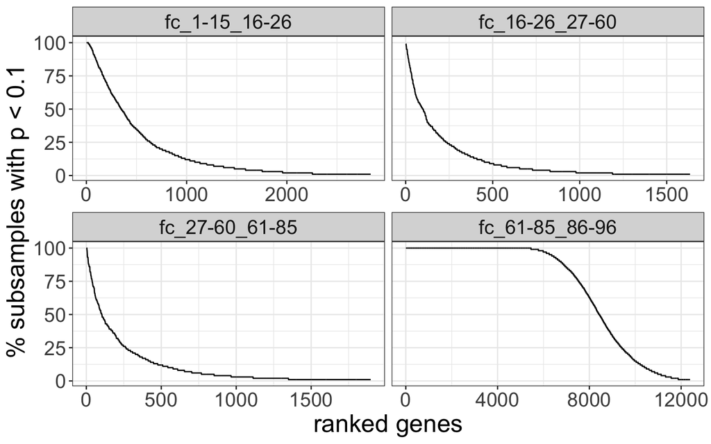

```r
# How often does each gene occur in the simulations?
ggplot(DE_subsampling, aes(x = as.numeric(rank), y = n)) +
  geom_line() +
  facet_wrap(~transition, scales = "free_x") +
  theme_bw() +
  xlab("ranked genes") +
  ylab("% subsamples with p < 0.1") +
  theme(text = element_text(size = 20))
```

```r
filter(DE_subsampling, n > 25) %>% summarize(n = n())
```

```
## # A tibble: 4 × 2
##   transition         n
##   <chr>          <int>
## 1 fc_1-15_16-26    630
## 2 fc_16-26_27-60   229
## 3 fc_27-60_61-85   260
## 4 fc_61-85_86-96  9381
```

## 4.3 Save results

```r
# Filtering: such that around 200 robust & significant DE genes per transition
thresholds <- data.frame('transition' = c('fc_1-15_16-37', 'fc_16-37_38-57',
                                           'fc_38-57_58-85', 'fc_58-85_86-96'),
                          'p_threshold' = c(0.002, 0.05, 0.1, 1e-21),
                          'n_threshold' = c(90, 45, 25, 99))

thresholds <- data.frame('transition' = c('fc_1-15_16-26', 'fc_16-26_27-60',
                                           'fc_27-60_61-85', 'fc_61-85_86-96'),
                          'p_threshold' = c(0.05, 0.1, 0.1, 1e-17),
                          'n_threshold' = c(50, 25, 20, 99),
                          'fc_threshold' = c(0.6, 0.4, 0.4, 1.6))

foldchanges_filtered <- foldchanges %>%
  left_join(DE_subsampling, by = c('gene', 'transition')) %>%
  left_join(thresholds) %>%
  filter(padj < p_threshold & n > n_threshold & abs_log2_fc > fc_threshold)
group_by(foldchanges_filtered, transition) %>% summarize(n = n())
```

```
## # A tibble: 4 × 2
##   transition         n
##   <chr>          <int>
## 1 fc_1-15_16-26    182
## 2 fc_16-26_27-60   162
## 3 fc_27-60_61-85   163
## 4 fc_61-85_86-96   184
```

```r
# Save the results for various thresholds on the adjusted p-value
p_0.05 <- foldchanges_filtered %>%
  group_by(gene, transition) %>%
  summarize(abs_log2_fc = mean(abs_log2_fc))
group_by(p_0.05, transition) %>% summarize(n = n())
```

```
## # A tibble: 4 × 2
##   transition         n
##   <chr>          <int>
## 1 fc_1-15_16-26    182
## 2 fc_16-26_27-60   162
## 3 fc_27-60_61-85   163
## 4 fc_61-85_86-96   183
```

```r
write.csv(p_0.05, paste0(dir, "Data/DE_var_p_n_200.csv"), row.names = FALSE)
```

## 4.4 Extract counts

```r
coldata <- as.data.frame(subset(colData(dds), select = c(names, Age, age_group, sex, source_name)))

count_data <- counts(dds, normalized = TRUE) %>%
  as.data.frame() %>%
  rownames_to_column(var = "ensembl_id") %>%
  mutate(gene = rowData(dds)$symbol) %>%
  gather(key = "names", value = "counts", -c(ensembl_id, gene)) %>%
  left_join(coldata, by = "names") %>%
  filter(gene != "")
write.csv(count_data, paste0(dir, "Data/count_data.csv"), row.names = FALSE)
head(count_data)
```

```
##        ensembl_id     gene      names    counts Age age_group  sex
## 1 ENSG00000000003   TSPAN6 SRR7093810  325.8738  12      1-15 male
## 2 ENSG00000000419     DPM1 SRR7093810  602.9198  12      1-15 male
## 3 ENSG00000000457    SCYL3 SRR7093810  205.8765  12      1-15 male
## 4 ENSG00000000460 C1orf112 SRR7093810  105.9794  12      1-15 male
## 5 ENSG00000000971      CFH SRR7093810  181.5254  12      1-15 male
## 6 ENSG00000001036    FUCA2 SRR7093810 2117.7447  12      1-15 male
##         source_name
## 1 Skin; Unspecified
## 2 Skin; Unspecified
## 3 Skin; Unspecified
## 4 Skin; Unspecified
## 5 Skin; Unspecified
## 6 Skin; Unspecified
```

```r
# Mean counts per age group
mean_counts <- count_data %>% group_by(ensembl_id, gene, age_group) %>%
  summarize(counts = mean(counts)) %>%
  ungroup()
write.csv(mean_counts, paste0(dir, "Data/mean_counts.csv"), row.names = FALSE)
head(mean_counts)
```

```
## # A tibble: 6 × 4
##   ensembl_id      gene   age_group counts
##   <chr>           <chr>  <fct>      <dbl>
## 1 ENSG00000000003 TSPAN6 1-15        352.
## 2 ENSG00000000003 TSPAN6 16-26       455.
## 3 ENSG00000000003 TSPAN6 27-60       470.
## 4 ENSG00000000003 TSPAN6 61-85       429.
## 5 ENSG00000000003 TSPAN6 86-96       621.
## 6 ENSG00000000419 DPM1   1-15        620.
```

# 5 Visualizations of DE genes

## 5.1 Distribution of p-values

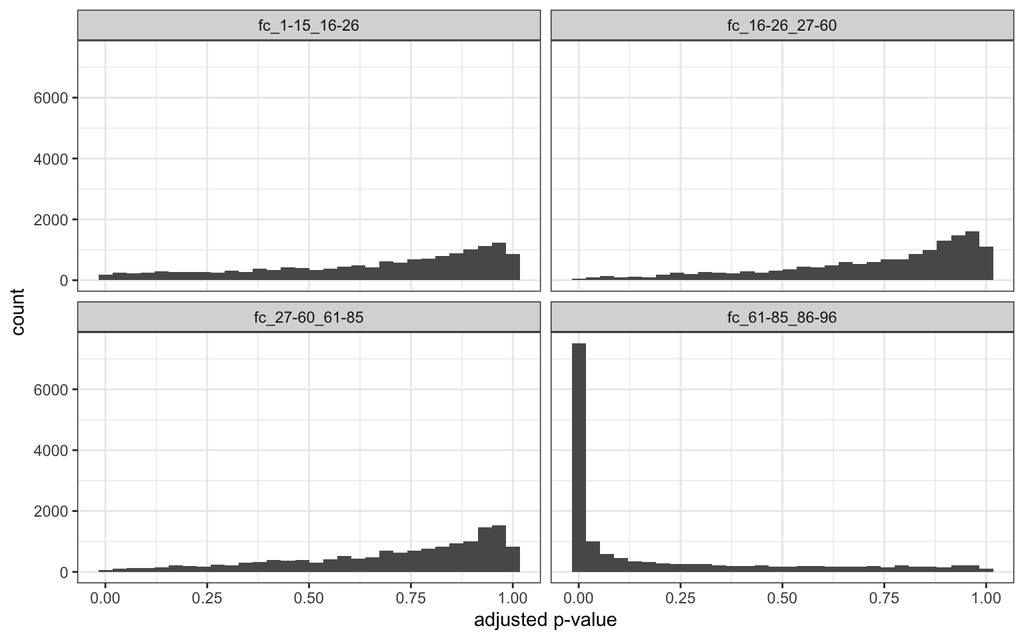

```r
ggplot(foldchanges, aes(x = padj)) +
  geom_histogram() +
  facet_wrap(~transition) +
  xlab('adjusted p-value') +
  theme_bw()
```

## 5.2 Intersection of DE genes

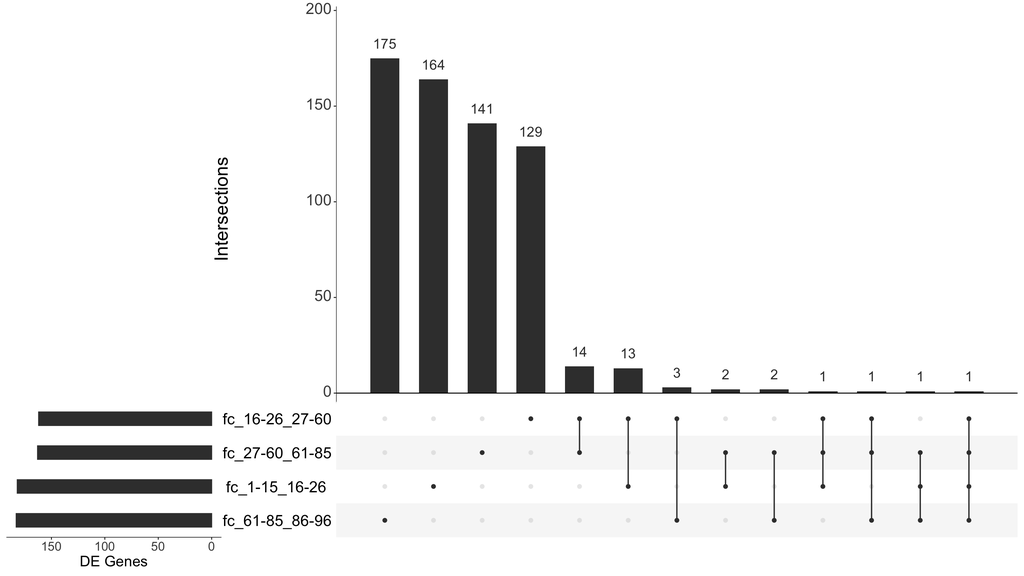

```r
#split DE genes into list of groups according to the transitions
transitions <- c("fc_1-15_16-26", "fc_16-26_27-60", "fc_27-60_61-85",
                 "fc_61-85_86-96")

top_list <- p_0.05 %>%
  mutate(transition = factor(transition, levels = transitions)) %>%
  group_by(transition) %>%
  group_split()
names(top_list) <- transitions
top_list <- lapply(top_list, function(list) list$gene)

upset(fromList(top_list), order.by = "freq", nsets = 9,
       mainbar.y.label = "Intersections", sets.x.label = "DE Genes",
       text.scale = c(2.5, 2.5, 2, 2, 2.5, 2.5), nintersects = 20,
       keep.order= TRUE)
```

## 5.3 PCA of the samples

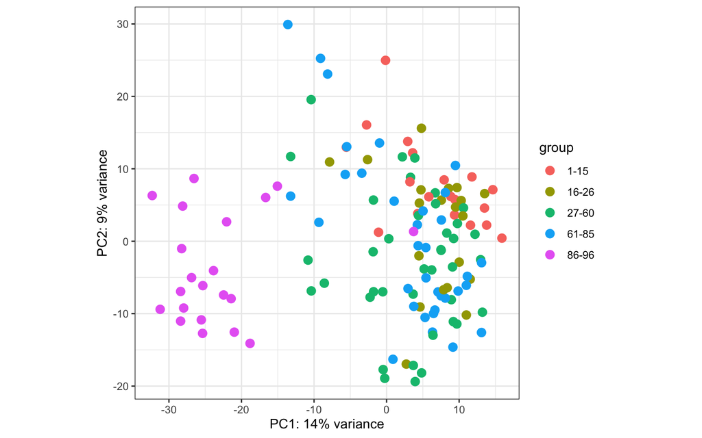

```r
# variance-stabilizing transformation
vsd <- vst(dds)
#vsd <- vsd[rownames(vsd) %in% lasso$ensembl_id,]
# PCA
plotPCA(vsd, intgroup = c("age_group")) +
  theme_bw()
```

```r
df_pca <- rownames_to_column(data.frame(t(assay(vsd)))) %>%
  left_join(rownames_to_column(subset(data.frame(colData(vsd)), select = c('Age', 'sex', 'source_name',
                                                               'Ethnicity', 'age_group'))))
```

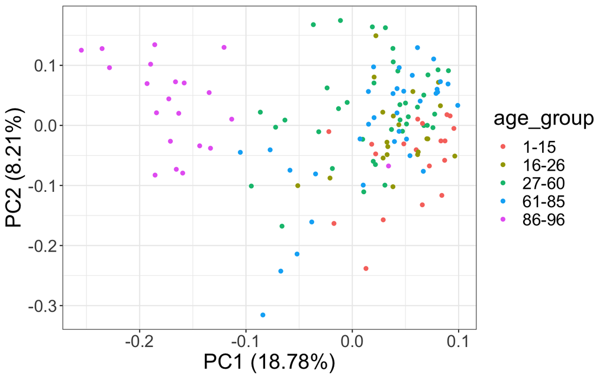

```r
pca <- prcomp(df_pca[, 2:(ncol(df_pca)-5)])
autoplot(pca, data = df_pca, colour = "age_group", x = 1, y = 2)  +
  theme_bw() +
  theme(text = element_text(size = 20))
```

```r
# Is another PC than 1 & 2 higher correlated to age?
cor(df_pca[, 15339], pca$x[, 1])
```

```
## [1] -0.5681123
```

```r
cor(df_pca[, 15339], pca$x[, 2])
```

```
## [1] 0.1992682
```

```r
cor(df_pca[, 15339], pca$x[, 3])
```

```
## [1] 0.1445767
```

```r
cor(df_pca[, 15339], pca$x[, 4])
```

```
## [1] -0.1405156
```

```r
cor(df_pca[, 15339], pca$x[, 5])
```

```
## [1] 0.02776604
```

```r
ggplot(runs_info, aes(x = Age)) +
  geom_histogram() +
  facet_wrap(~source_name)
```

[output not shown]

```r
set.seed(142)
umap_fit <- umap(df_pca[, 2:(ncol(df_pca)-5)])

umap_df <- umap_fit$layout %>%
  as.data.frame()%>%
  dplyr::rename(UMAP1="V1", UMAP2="V2") %>%
  mutate(sample=df_pca$rowname) %>%
  inner_join(subset(data.frame(colData(vsd)),
                    select = c('Age', 'sex', 'source_name', 'Ethnicity', 'age_group')) %>%
               rownames_to_column(var = "sample"))
```

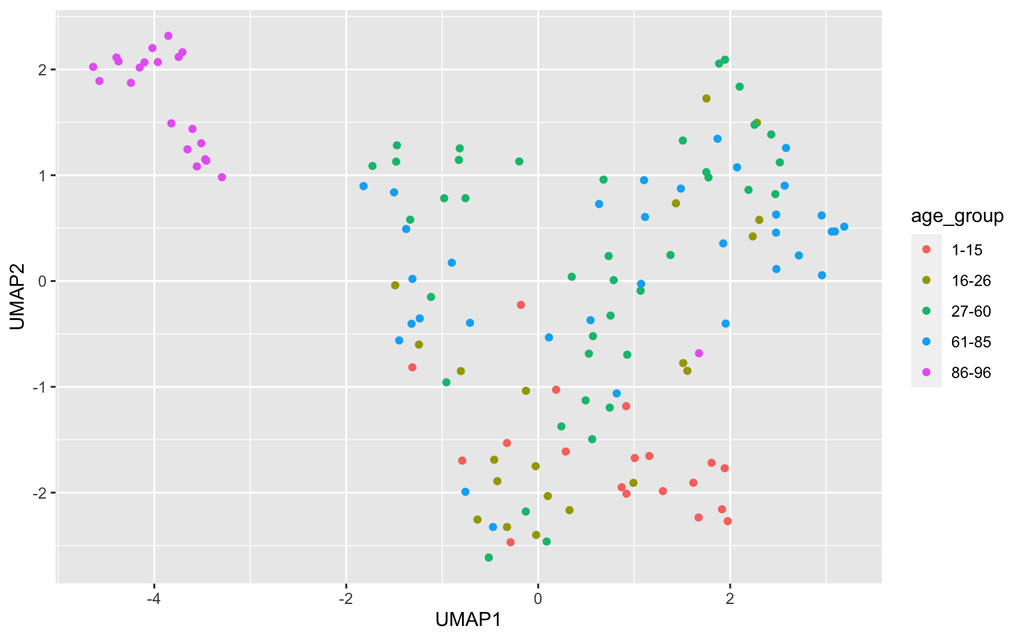

```r
ggplot(umap_df, aes(x = UMAP1, y = UMAP2, color = age_group)) +
  geom_point()
```

```r
# save counts with variance-stabilizing transformation for MEFISTO
count_data_vst <- assay(vsd) %>%
  as.data.frame() %>%
  rownames_to_column(var = "ensembl_id") %>%
  mutate(gene = rowData(vsd)$symbol) %>%
  gather(key = "names", value = "counts", -c(ensembl_id, gene)) %>%
  left_join(coldata, by = "names") %>%
  filter(gene != "")
write.csv(count_data_vst, paste0(dir, "MOFA/Data/vst_counts.csv"), row.names = FALSE)
```

## 5.4 Gene expression of following age intervals

```r
# Mean counts per age group
mean_counts <- count_data_vst %>% group_by(ensembl_id, gene, age_group) %>%
  summarize(counts = mean(counts)) %>%
  ungroup()
#write.csv(mean_counts, paste0(dir, "Data/mean_counts.csv"), row.names = FALSE)
head(mean_counts)
```

```
## # A tibble: 6 × 4
##   ensembl_id      gene   age_group counts
##   <chr>           <chr>  <fct>      <dbl>
## 1 ENSG00000000003 TSPAN6 1-15        8.74
## 2 ENSG00000000003 TSPAN6 16-26       9.08
## 3 ENSG00000000003 TSPAN6 27-60       9.12
## 4 ENSG00000000003 TSPAN6 61-85       9.01
## 5 ENSG00000000003 TSPAN6 86-96       9.46
## 6 ENSG00000000419 DPM1   1-15        9.48
```

```r
expr_fc <- foldchanges %>% separate(transition, c("fc", "t0", "t1"), sep = "_", remove = FALSE) %>%
  left_join(dplyr::rename(mean_counts, t0 = age_group, counts_t0 = counts)) %>%
  left_join(dplyr::rename(mean_counts, t1 = age_group, counts_t1 = counts)) %>%
  subset(select = c(ensembl_id, gene, transition, counts_t0, counts_t1, log2FoldChange, abs_log2_fc, padj)) %>%
  left_join(mutate(p_0.05, selected = 'True')) %>%
  mutate(selected = replace_na(selected, 'False')) %>%
  arrange(selected)
tail(expr_fc)
```

```
##            ensembl_id     gene     transition counts_t0 counts_t1
## 59827 ENSG00000134072    CAMK1 fc_27-60_61-85  8.442259  8.747956
## 59828 ENSG00000127990     SGCE fc_27-60_61-85 10.331449  9.988284
## 59829 ENSG00000109099    PMP22 fc_16-26_27-60 10.510646 10.889737
## 59830 ENSG00000185650  ZFP36L1 fc_16-26_27-60 11.497860 11.894587
## 59831 ENSG00000144445  KANSL1L fc_16-26_27-60  7.555647  7.788310
## 59832 ENSG00000134291 TMEM106C fc_16-26_27-60 10.267236  9.883646
##       log2FoldChange abs_log2_fc        padj selected
## 59827     -0.4072087   0.4072087 0.003906075     True
## 59828      0.4068102   0.4068102 0.011977694     True
## 59829     -0.4064454   0.4064454 0.053967730     True
## 59830     -0.4054953   0.4054953 0.055776175     True
## 59831     -0.4029404   0.4029404 0.048555939     True
## 59832      0.4001542   0.4001542 0.056077089     True
```

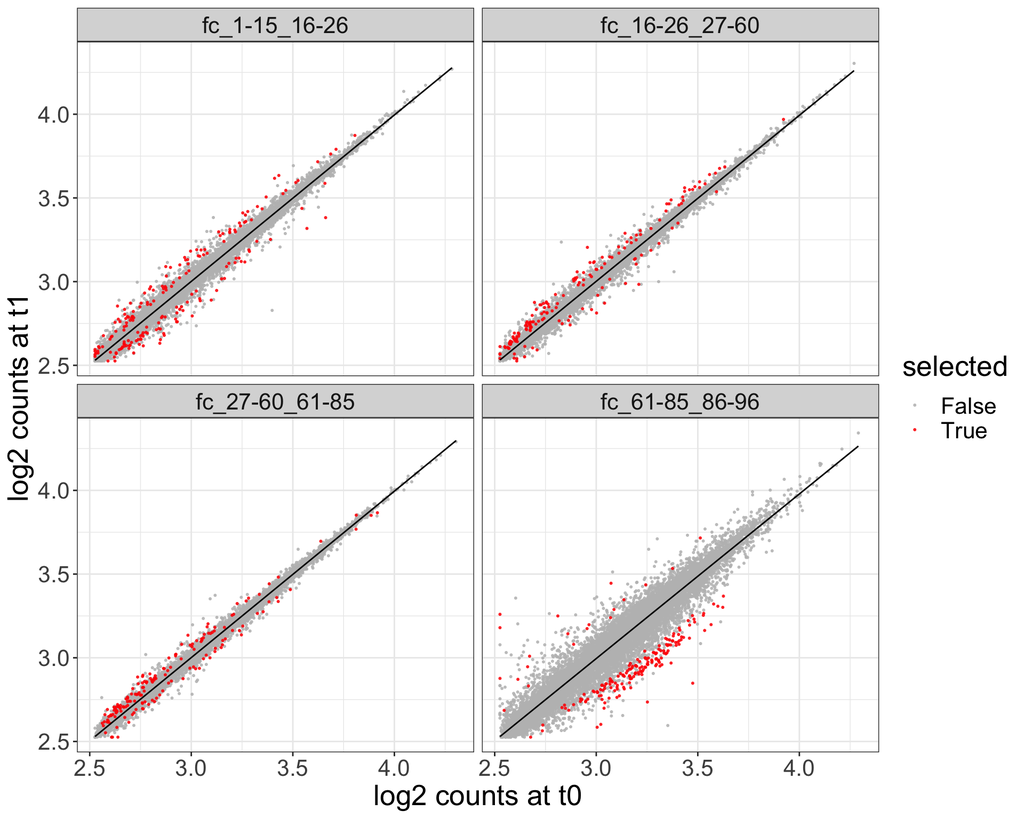

```r
group.colors <- c(False = "grey", True = "red")

ggplot(expr_fc, aes(x = log2(counts_t0 + 0.1), y = log2(counts_t1 + 0.1), color = selected)) +
  geom_point(size = 0.4, alpha = 0.8) +
  facet_wrap(~transition) +
  theme_bw() +
  geom_smooth(method='lm', color = 'black', size = 0.5) +
  theme(text = element_text(size = 15)) +
  scale_color_manual(values=group.colors) +
  xlab("log2 counts at t0") +
  ylab("log2 counts at t1") +
  theme(text = element_text(size = 20))
```

**Why are some of the selected genes so close to the black line?**

```r
expr_fc %>%
  mutate(diff = abs((counts_t0 - counts_t1)/(counts_t1+0.1))) %>%
  filter(selected == "True") %>%
  arrange(diff) %>% head()
```

```
##        ensembl_id   gene     transition counts_t0 counts_t1 log2FoldChange
## 1 ENSG00000163347  CLDN1 fc_27-60_61-85  5.960687  6.000591     -1.7967893
## 2 ENSG00000085721   RRN3 fc_16-26_27-60  5.659593  5.718654    -23.9218949
## 3 ENSG00000156804 FBXO32 fc_27-60_61-85  8.859114  8.973908     -0.8124634
## 4 ENSG00000105767  CADM4 fc_27-60_61-85  6.492881  6.588130     -0.7041079
## 5 ENSG00000128606 LRRC17 fc_27-60_61-85  6.648137  6.755896     -1.1382759
## 6 ENSG00000165091   TMC1 fc_27-60_61-85  6.067066  6.169373     -1.2409446
##   abs_log2_fc         padj selected        diff
## 1   1.7967893 6.273698e-02     True 0.006541141
## 2  23.9218949 2.883539e-06     True 0.010150158
## 3   0.8124634 7.454659e-02     True 0.012651059
## 4   0.7041079 9.579324e-02     True 0.014241549
## 5   1.1382759 5.835389e-02     True 0.015717769
## 6   1.2409446 6.890542e-02     True 0.016318476
```

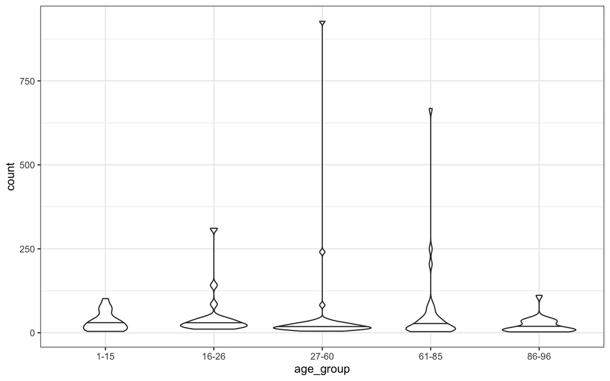

```r
geneCounts <- plotCounts(dds, gene = "ENSG00000128606", intgroup = c("age_group"),
                         returnData = TRUE, normalized = TRUE)
ggplot(geneCounts, aes(x = age_group, y = count)) +
  #geom_beeswarm(cex = 3) +
  geom_violin(draw_quantiles = c(0.5), trim = TRUE) +
  theme_bw()
```

## 5.5 Volcano Plot

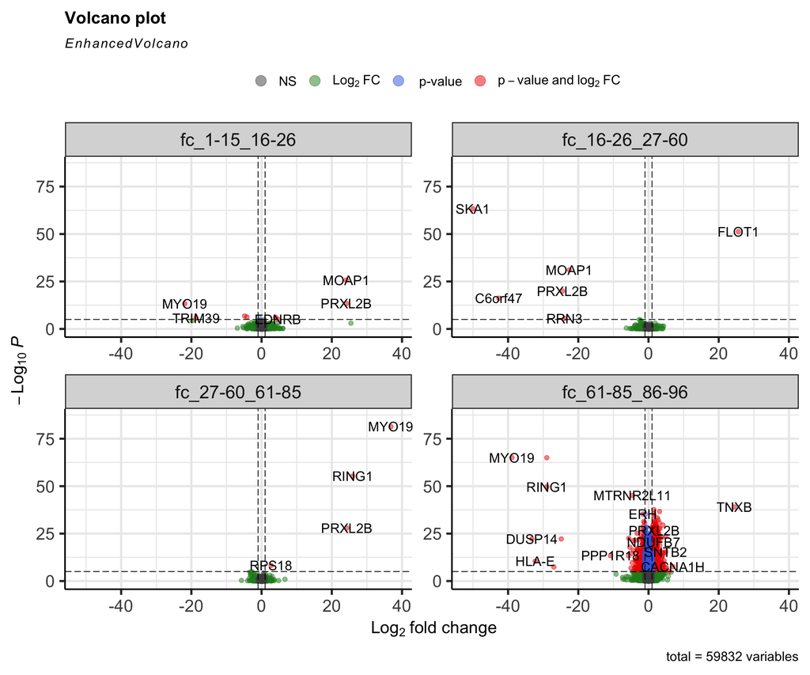

```r
EnhancedVolcano(expr_fc,
  lab = expr_fc$gene,
  x = 'log2FoldChange',
  y = 'padj') +
  facet_wrap(~transition, scales = "free")
```

# 6 Hierarchical clustering to define the age groups

## 6.1 LASSO

```r
df = data.frame(t(assay(gse))) %>%
  rownames_to_column(var = "sample") %>%
  left_join(rownames_to_column(subset(data.frame(colData(gse)), select = c("Age")), var = 'sample'))
model <- glmnet(subset(df, select = -c(sample, Age)), df$Age, alpha = 1, lambda = 1)
lasso <- data.frame(ensembl_id = dimnames(coef(model))[[1]], coefficient = matrix(coef(model))) %>%
  filter(coefficient != 0) %>%
  filter(ensembl_id != "(Intercept)") %>%
  arrange(desc(abs(coefficient)))
head(lasso)
```

```
##        ensembl_id coefficient
## 1 ENSG00000167705   0.6262528
## 2 ENSG00000167850   0.3578815
## 3 ENSG00000116990  -0.3483218
## 4 ENSG00000184313   0.2964550
## 5 ENSG00000198633   0.2569621
## 6 ENSG00000188001   0.2006821
```

## 6.2 Hierarchical clustering on LASSO features

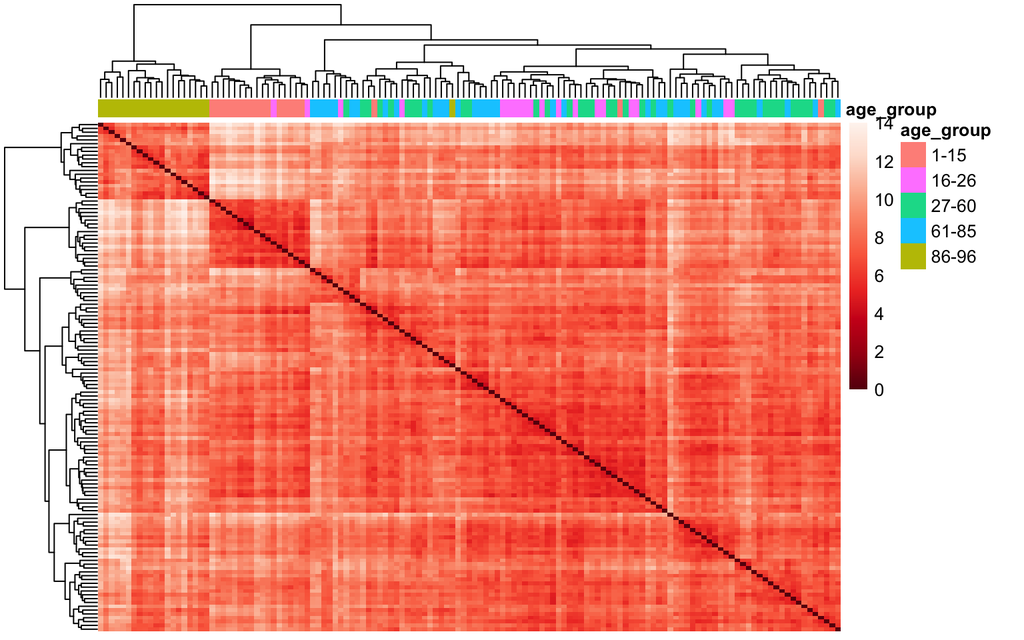

```r
#lasso <- read.delim(paste0(dir, "MOFA/Data/lasso_coef.csv"),
 #                                    sep = ",", header = TRUE)
# subset to features from LASSO regression
#vsd <- vsd[rownames(vsd) %in% lasso$ensembl_id,]

# use MEFISTO genes for clustering
#mefisto_pos <- read.delim(paste0(dir, "MOFA/Data/top_genes_pos_0.1.csv"),
#                                     sep = ",", header = TRUE)
#mefisto_neg <- read.delim(paste0(dir, "MOFA/Data/top_genes_neg_0.1.csv"),
#                                     sep = ",", header = TRUE)
#MEFISTO_genes <- bind_rows(mefisto_pos, mefisto_neg)
#
#vsd <- vsd[rowData(vsd)$gene_name %in% MEFISTO_genes$gene,]

sampleDists <- dist(t(assay(vsd[rownames(vsd) %in% lasso$ensembl_id,])))
sampleDistMatrix <- as.matrix(sampleDists)

annotation <- data.frame(subset(colData(vsd), select = c(age_group)))
#annotation <- pred_age %>% dplyr::rename(Age = predicted_age) %>%
#  left_join(age_groups) %>%
#  column_to_rownames(var = "names") %>%
#  subset(select = age_group)

colors <- colorRampPalette(rev(brewer.pal(9, "Reds")))(255)

pheatmap(sampleDistMatrix,
         clustering_distance_rows = sampleDists,
         clustering_distance_cols = sampleDists, annotation_col = annotation,
         clustering_method = "ward.D2",
         col = colors, show_colnames = F, show_rownames = F)
```

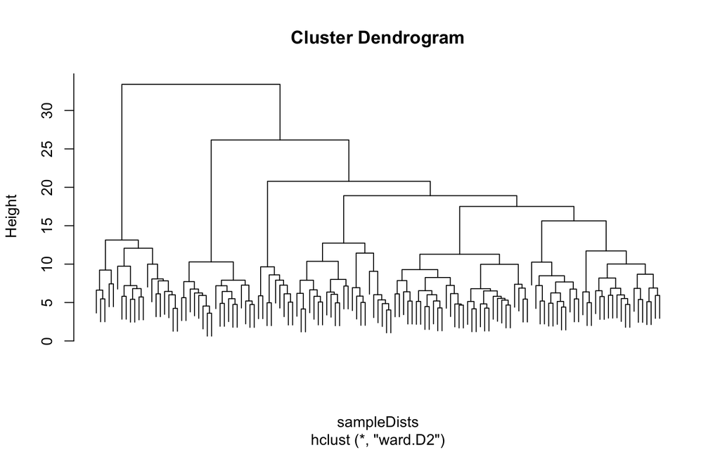

```r
dend <- hclust(sampleDists, method = 'ward.D2')
plot(dend, labels = FALSE)
```

```r
annotation <- data.frame(subset(colData(vsd), select = c(Age)))
#annotation <- pred_age %>% dplyr::rename(Age = predicted_age) %>%
#  left_join(age_groups) %>%
#  column_to_rownames(var = "names")

clusters <- data.frame(cluster = cutree(dend, 6)) %>%
  rownames_to_column() %>%
  #left_join(data.frame(subset(annotation, select = Age)) %>% rownames_to_column()) %>%
  left_join(annotation %>% rownames_to_column()) %>%
  mutate(Age = as.numeric(Age)) %>%
  mutate(cluster = factor(cluster, levels = seq(1, 6, 1)))
```

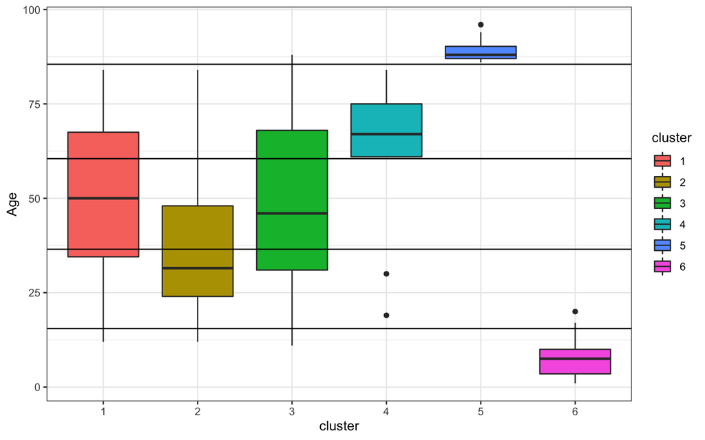

```r
ggplot(clusters, aes(x = cluster, y = Age, fill = cluster)) +
  geom_boxplot() +
  theme_bw() +
  geom_hline(yintercept = c(15.5, 36.5, 60.5, 85.5))
```

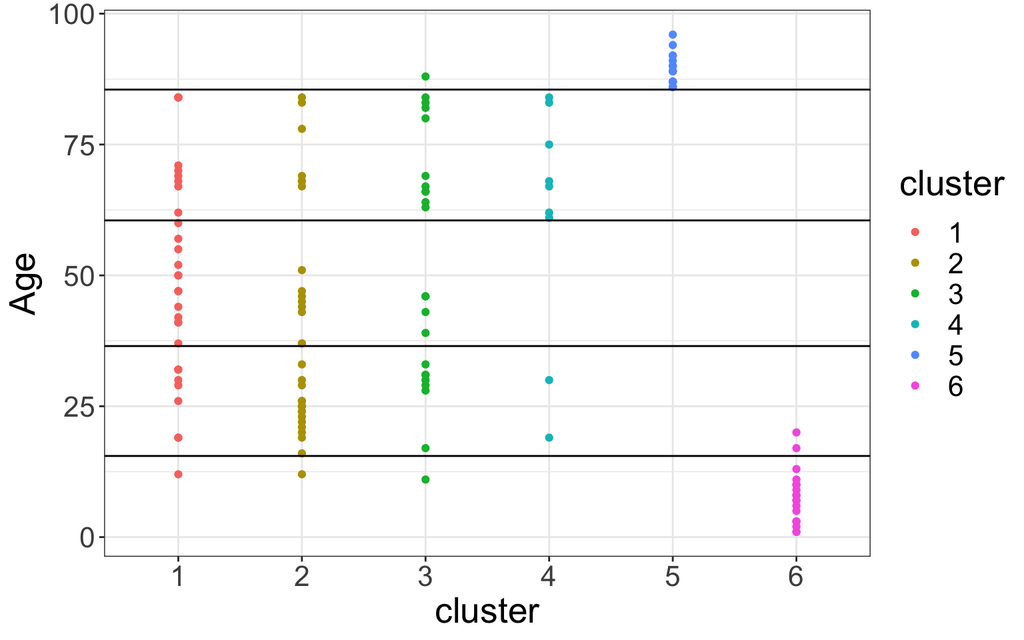

```r
ggplot(clusters, aes(x = cluster, y = Age, color = cluster)) +
  geom_point() +
  theme_bw() +
  geom_hline(yintercept = c(15.5, 36.5, 60.5, 85.5))+
  theme(text = element_text(size = 20))
```